# Reproducible Research: Peer Assessment 1

Luis Urbina

Saturday, May 16, 2015

## Loading and preprocessing the data

### 1.1)

```r
    wd <- getwd()
    if(!is.null(wd)) setwd(wd)
    da <- read.table(unz("activity.zip", "activity.csv"), header=T, sep=",")
```

### 1.2)

In order to know the dataset behavior, a short exploratory data analysis of the dataset is done using the `str()`function.

```r
    str(da)
```

```
## 'data.frame':    17568 obs. of  3 variables:
##  $ steps   : int  NA NA NA NA NA NA NA NA NA NA ...
##  $ date    : Factor w/ 61 levels "2012-10-01","2012-10-02",..: 1 1 1 1 1 1 1 1 1 1 ...
##  $ interval: int  0 5 10 15 20 25 30 35 40 45 ...
```

The data frame has 17,568 observaciones and three variables. The variables steps and interval are the ‘integer’ data type. The variable steps has also NA values. There is not need to transform or process the **da** data frame in order to perform the analysis.

## What is mean total number of steps taken per day?

### 2.1)

The NA values are going to be ignnored in this part of the analysis. To calculate the total number of steps taken per day, the `aggregate()` function is used. The new data frame is named **tidy.steps**.

The **total number of steps per day** is shown below. Notice that there are some days that do not have counted steps and they are not listed. In total are listed only 53 days, information obtained using the `dim()` function.

```r
    tidy.steps <- aggregate(.~date, data=da, sum)
    tidy.steps[,c(1,2)]
```

```
##          date steps
## 1  2012-10-02   126
## 2  2012-10-03 11352
## 3  2012-10-04 12116
## 4  2012-10-05 13294
## 5  2012-10-06 15420
## 6  2012-10-07 11015
## 7  2012-10-09 12811
## 8  2012-10-10  9900
## 9  2012-10-11 10304
## 10 2012-10-12 17382
## 11 2012-10-13 12426
## 12 2012-10-14 15098
## 13 2012-10-15 10139
## 14 2012-10-16 15084
```

[output cut: 39 more lines]

```r
    dim(tidy.steps)
```

```
## [1] 53  3
```

### 2.2) Histogram

A **histrogram of the total number of steps taken each day** is build and shown next. Notice that the maximum frequency (y-axes) is around 10 according to the graphics.

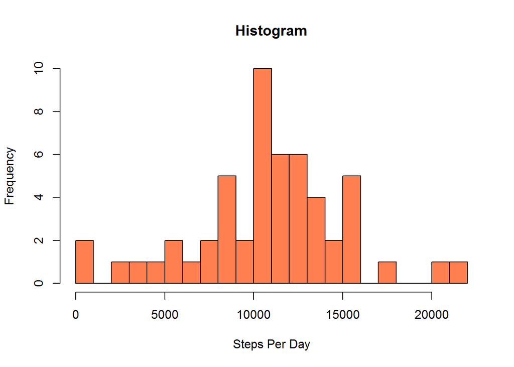

```r
    hist(tidy.steps$steps,breaks=20,col='coral',
         xlab='Steps Per Day',
         main='Histogram')
```

### 2.3) Mean and Median

Following is reported the **mean** of the total number of **steps taken per each day**. Results are shown:

```r
    tidy.date.mean <- aggregate(.~date, data=da, mean)
    tidy.date.mean[,c(1,2)]
```

```
##          date      steps
## 1  2012-10-02  0.4375000
## 2  2012-10-03 39.4166667
## 3  2012-10-04 42.0694444
## 4  2012-10-05 46.1597222
## 5  2012-10-06 53.5416667
## 6  2012-10-07 38.2465278
## 7  2012-10-09 44.4826389
## 8  2012-10-10 34.3750000
## 9  2012-10-11 35.7777778
## 10 2012-10-12 60.3541667
## 11 2012-10-13 43.1458333
## 12 2012-10-14 52.4236111
## 13 2012-10-15 35.2048611
## 14 2012-10-16 52.3750000
```

[output cut: 39 more lines]

It is also reported the **median** of the total number of **steps taken per each day**. Results are shown:

```r
    tidy.date.median <- aggregate(.~date, data=da, median)
    tidy.date.median[,c(1,2)]
```

```
##          date steps
## 1  2012-10-02     0
## 2  2012-10-03     0
## 3  2012-10-04     0
## 4  2012-10-05     0
## 5  2012-10-06     0
## 6  2012-10-07     0
## 7  2012-10-09     0
## 8  2012-10-10     0
## 9  2012-10-11     0
## 10 2012-10-12     0
## 11 2012-10-13     0
## 12 2012-10-14     0
## 13 2012-10-15     0
## 14 2012-10-16     0
```

[output cut: 39 more lines]

## What is the average daily activity pattern?

### 3.1) Time Series Plot

It is calculated the **mean of the number of steps taken for each 5-minute interval**. The new data frame is named **tidy.interval**. It is determined it has 288 observations using the `dim()` function.

```r
    tidy.interval <- aggregate(.~interval, data=da, mean)
    dim(tidy.interval)
```

```
## [1] 288   3
```

A **time series plot** of the 5-minute interval (x-axis) and the average number of steps taken, averaged across all days (y-axis) is shown next:

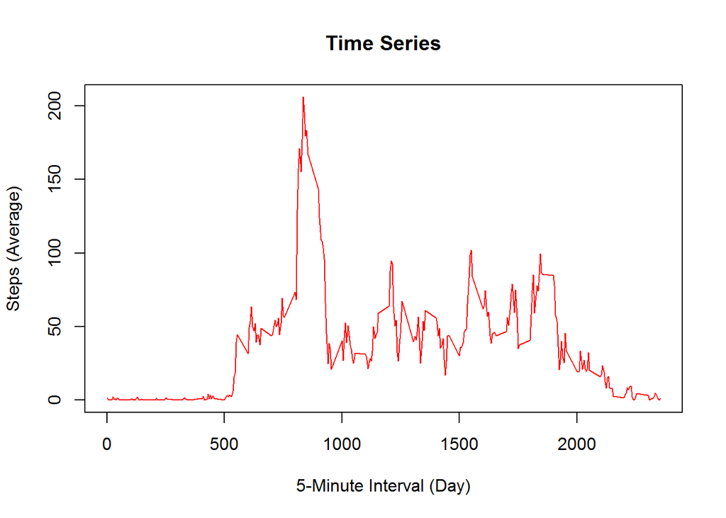

```r
    plot(tidy.interval[,c(1,2)], type='l', col='red',
         main='Time Series',
         xlab='5-Minute Interval (Day)',
         ylab='Steps (Average)')
```

### 3.2) Maximum Number of Steps

The **maximum number of steps** each 5-minute interval, on average across all the days, is calculated next.

```r
    max(tidy.interval[,2])
```

[1] 206.1698

## Imputing missing values

### 4.1) Total Number of Missing Values

To calculate the **total number of missing values** in the dataset, it is used the `apply()` function. First it is identified the rows with NA values, and next they are counted using the `sum()` funciton.

```r
    na.identifier <- apply(da, 1, function(x){any(is.na(x))})
    total.na <- sum(na.identifier)
    total.na
```

```
## [1] 2304
```

The total number of missing values is 2304.

### 4.2) Strategy for Imputing Missing Data

The strategy to fill the missing values is:

1. first, calculate the mean for the 5-minute interval
2. second, replace the 5-minute interval mean in each missing value using a for-loop. It creates a new data set.

Firs, it is calculated the mean for the 5-minute interval. It is named the **interval.mean**. Code is next:

```r
    interval.mean <- mean(tidy.interval$steps)
    interval.mean
```

```
## [1] 37.3826
```

Now this interval.mean value will be replaced in any NA value in the dataset **da**, using a `for()` loop.

### 4.3) Replacing Missing Values

A new dataset is created in which all the NA values in **da** have been replaced using a for-loop. The new dataset is named **da.full**. The algorithm is next:

```r
    da.full <- da
    for (i in 1:(length(da.full[,1]) )) {
        if (is.na(da.full$steps[i]))
            da.full$steps[i] <- interval.mean
    }
```

### 4.4) What is the impact of imputing missing data on the estimates of the total daily number of steps?

### 4.4.1) Histogram After Replaced Missing Values

With replacement of missing values, the frequency of the steps per day have increased, keeping the same distribution. As can be see in the graphics below, the top frequency is over 15.

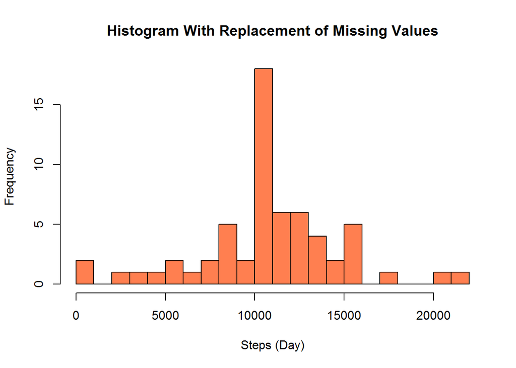

```r
    tidy.steps.full <- aggregate(.~date, data=da.full, sum)
    hist(tidy.steps.full$steps,n=20,col='coral',
         xlab='Steps (Day)',
         main='Histogram With Replacement of Missing Values')
```

### 4.4.2) Mean

```r
    tidy.date.mean.full <- aggregate(.~date, data=da.full, mean)
    tidy.date.mean.full[,c(1,2)]
```

```
##          date      steps
## 1  2012-10-01 37.3825996
## 2  2012-10-02  0.4375000
## 3  2012-10-03 39.4166667
## 4  2012-10-04 42.0694444
## 5  2012-10-05 46.1597222
## 6  2012-10-06 53.5416667
## 7  2012-10-07 38.2465278
## 8  2012-10-08 37.3825996
## 9  2012-10-09 44.4826389
## 10 2012-10-10 34.3750000
## 11 2012-10-11 35.7777778
## 12 2012-10-12 60.3541667
## 13 2012-10-13 43.1458333
## 14 2012-10-14 52.4236111
```

[output cut: 47 more lines]

Both averages, with replacement and without replacement, of the steps media for interval are the same. Numeric comparison is shown below.

```r
    mean(tidy.date.mean$steps)
```

```
## [1] 37.3826
```

```r
    mean(tidy.date.mean.full$steps)
```

```
## [1] 37.3826
```

### 4.4.3) Median

```r
    tidy.date.median.full <- aggregate(.~date, data=da.full, median)
    tidy.date.median.full[,c(1,2)]
```

```
##          date   steps
## 1  2012-10-01 37.3826
## 2  2012-10-02  0.0000
## 3  2012-10-03  0.0000
## 4  2012-10-04  0.0000
## 5  2012-10-05  0.0000
## 6  2012-10-06  0.0000
## 7  2012-10-07  0.0000
## 8  2012-10-08 37.3826
## 9  2012-10-09  0.0000
## 10 2012-10-10  0.0000
## 11 2012-10-11  0.0000
## 12 2012-10-12  0.0000
## 13 2012-10-13  0.0000
## 14 2012-10-14  0.0000
```

[output cut: 47 more lines]

The averages of the median change, with replacement and without replacement, of the steps median for interval. Numeric comparison is shown below.

```r
    mean(tidy.date.median$steps)
```

```
## [1] 0
```

```r
    mean(tidy.date.median.full$steps)
```

```
## [1] 4.902636
```

## Are there differences in activity patterns between weekdays and weekends?

### 5.1) Algorithem

The next algorithm is going to create a new factor variable in the **da.full** dataset with two levels, “weekday” and “weekend”, indicating whether a given date is a weekday or weekend day. This new variable is named **day**. For this purpose, it is used the `weekdays()` function.

```r
    da.full$aux <- weekdays(as.Date(da.full$date))
    days <- c('Monday','Tuesday','Wednesday','Thursday','Friday')
    da.full$day <- ""

    for (i in 1:(length(da.full[,1]) )) {
        if (da.full$aux[i] %in% days)
            da.full$day[i] <- "weekday"
        else
            da.full$day[i] <- "weekend"
    }
```

Below is shown few rows of the new dataset **da.full** showing the new created factor **day** and the dataset dimension.

```r
    dim(da.full)
```

```
## [1] 17568     5
```

```r
    head(da.full)
```

```
##     steps       date interval    aux     day
## 1 37.3826 2012-10-01        0 Monday weekday
## 2 37.3826 2012-10-01        5 Monday weekday
## 3 37.3826 2012-10-01       10 Monday weekday
## 4 37.3826 2012-10-01       15 Monday weekday
## 5 37.3826 2012-10-01       20 Monday weekday
## 6 37.3826 2012-10-01       25 Monday weekday
```

### 5.2) Panel Plot to Compare Interval Acrross Weekdays and Weekends

A **panel plot** containing a time series plot fo the 5-minute interval and the average number of steps taken, average, is shown below.

```r
    require(stats)
    require(lattice)
```

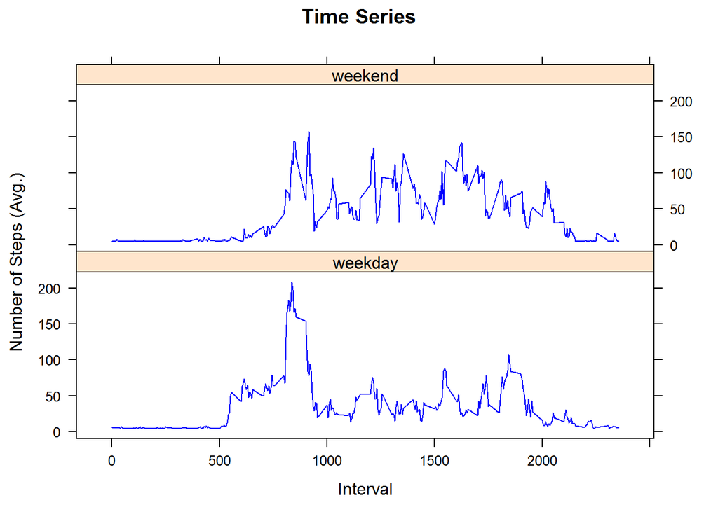

```r
    da.weekend <- aggregate(.~interval,
                     data=da.full[da.full$day=='weekend',c(1,2,3)],mean)
    da.weekday <- aggregate(.~interval,
                     data=da.full[da.full$day=='weekday',c(1,2,3)],mean)

    da.weekend$day <- 'weekend'
    da.weekday$day <- 'weekday'

    da.day <- rbind(da.weekday, da.weekend)
    xyplot(steps~interval|day, data=da.day, type='l', col='blue',
           layout=c(1,2), main='Time Series',
           xlab='Interval',ylab='Number of Steps (Avg.)')
```